# Tarea 1: Instalación y visualización

```r
install.packages("tidyverse")
install.packages("devtools")
install.packages("gapminder")
devtools::install_github("tereom/estcomp")
devtools::install_github("diegovalle/mxmaps")
```

```r
library(tidyverse)
library(devtools)
library(gapminder)
library(estcomp)
library("mxmaps")
```

```r
data(enlacep_2013)
glimpse(enlacep_2013)
```

## Preguntas:

1. ¿Cuáles estados tienen mejor y peor desempeño?
2. ¿El desempeño por estado depende del sostenimiento de la escuela?
3. ¿En cuáles estados se encuentran las escuelas con mayor porcentaje de copia?

### Pregunta 1: ¿Cuáles estados tienen mejor y peor desempeño?

Se explorará el desempeño entendido como resultado de la prueba en Español para tercero de primaria.

```r
#Limpieza superficial
#Crea nueva variable de estado desde el CCT de la escuela
enlacep_2013['estado'] = substr(enlacep_2013$CCT, start = 1, stop = 2)
enlacep_2013$estado <- sapply(enlacep_2013$estado, as.numeric)
```

[output not shown]

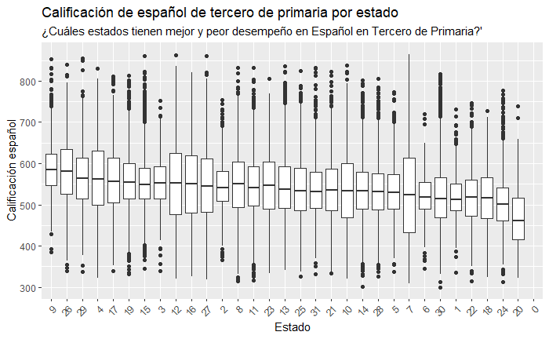

```r
enlacep_2013_e <- subset(enlacep_2013, estado<32)
ggplot(enlacep_2013_e, aes(x = reorder(estado, -PUNT_ESP_3, mean, na.rm = TRUE),
    y = PUNT_ESP_3)) +
    geom_boxplot()   +
  theme(axis.text.x = element_text(angle = 45, hjust = 1)) +
    labs(title = "Calificación de español de tercero de primaria por estado",
        subtitle = "¿Cuáles estados tienen mejor y peor desempeño en Español en Tercero de Primaria?'", x = "Estado", y = "Calificación español")
ggsave('~/p1.png')
```

Por un lado, los estados con el mejor promedio en español en tercero de primaria son: Distrito Federal (ahora, Ciudad de México), Sonora y Tlaxcala.

Por otro lado, los estados con el peor promedio en español en tercero de primaria son: Oaxaca, San Luis Potosí, y Nayarit.

### Pregunta 2:

¿El desempeño por estado depende del sostenimiento de la escuela?

Por sostenimiento nos referimos a la fuentes de financiamiento de la escuela. Las principales son Federal (D), estatal (E), particular (P) y CONAFE (K)

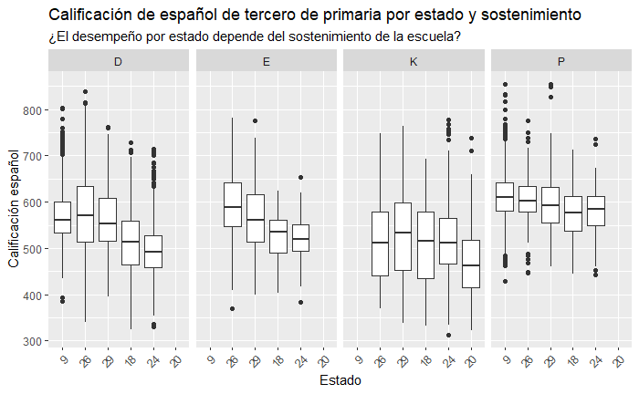

```r
#Sost se refiere al sostenimiento de la escuela. Los principales son Federal (D), estatal (E) y particular (P)
enlacep_2013_e['sost'] <- substr(enlacep_2013_e$CCT, start = 3, stop = 3)
enlacep_2013_s <- subset(enlacep_2013_e, sost=='D' | sost =='P' | sost=='E'| sost=='K' )
enlacep_2013_es <- subset(enlacep_2013_s, estado==9 | estado ==26| estado==29 | estado==18 | estado ==24| estado==20)
ggplot(enlacep_2013_es, aes(x = reorder(estado, -PUNT_ESP_3, mean, na.rm = TRUE),
    y = PUNT_ESP_3)) +
    geom_boxplot()   +
  facet_grid(~ sost) +
  theme(axis.text.x = element_text(angle = 45, hjust = 1)) +
    labs(title = "Calificación de español de tercero de primaria por estado y sostenimiento",
        subtitle = "¿El desempeño por estado depende del sostenimiento de la escuela?", x = "Estado", y = "Calificación español")
ggsave('~/p2.png')
```

Sin embargo, las diferencias entre estados sí cambian. Por ejemplo, la diferencia entre las escuelas estatales es mayor que la diferencia de escuelas privadas. En otras palabras, hay menos variación entre estados entre escuelas privadas y estatales. Del mismo modo, el rango interquartil dentro de un mismo estado es menor en las privadas que en las escuelas CONAFE. Esto se puede interpretar como que la calidad de las escuelas privadas suele ser más estable que en las escuelas del CONAFE.

Cabe destacar que Oaxaca, en el 2013, solo participaron escuelas CONAFE y que en el Distrito Federal o no hay o no participaron escuelas comunitarias (CONAFE).

### Pregunta 3: ¿En cuáles estados se encuentran las escuelas con mayor porcentaje de copia?

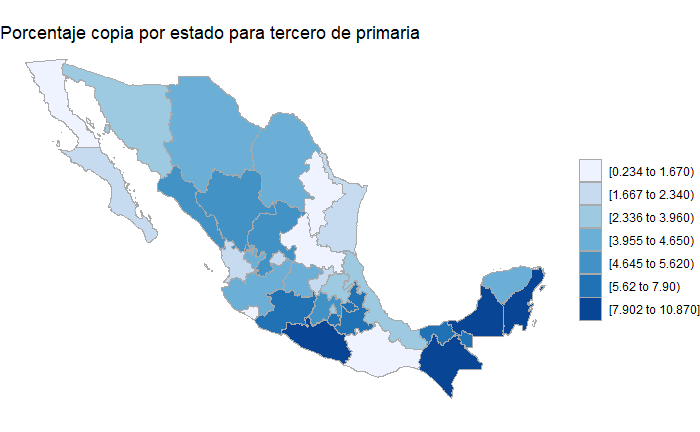

```r
by_edo<- group_by(enlacep_2013, estado)
edo_porc_copia <- summarise(by_edo, promedio = mean(ALUM_NOCONFIABLE_3/ALUM_EVAL_3, na.rm=TRUE))
edo_porc_copia <- subset(edo_porc_copia, estado<33 & estado>0)
edo_porc_copia$promedio <- edo_porc_copia$promedio*100
colnames(edo_porc_copia)[1] <- "region"
colnames(edo_porc_copia)[2] <- "value"
mxstate_choropleth(edo_porc_copia,
                   title = "Porcentaje copia por estado para tercero de primaria")
ggsave('~/p3.png')
```

[output not shown]